# Quality control and filtration

Sergey Naumenko

2020-06-26

# 1 Overview

- Researcher: Robert Fenster
- Experiment: fenster2020_morphine_macaques_hbc03961

```r
# Metadata
metadata <- read_csv("meta/metadata.csv", col_types = "ccf")
if (file.exists("data/seurat.metadata.RDS")){
    seurat_object <- readRDS("data/seurat.metadata.RDS")
}else{
    seurat_object <- readRDS("data/seurat.bcbio.RDS")
    # Mitochondrial ratio
    seurat_object$log10GenesPerUMI <- log10(seurat_object$nFeature_RNA) / log10(seurat_object$nCount_RNA)
    mito_genes <- read_csv("tables/mitochondrial.ensid.csv")
    # Compute percent mito ratio
    seurat_object$mitoRatio <- PercentageFeatureSet(object = seurat_object,
                                                features = mito_genes$ensembl_gene_id)
    seurat_object$mitoRatio <- seurat_object@meta.data$mitoRatio / 100

    # note if trimmed sample barcodes used or not
    metadata1 <- seurat_object@meta.data
    metadata1$cells <- rownames(metadata1)
    metadata1 <- metadata1 %>%
        dplyr::rename(seq_folder = orig.ident,
                      nUMI = nCount_RNA,
                      nGene = nFeature_RNA)

    metadata1$sample_id <- str_split_fixed((metadata1$cells),":",2)[,1]

    metadata2 <- metadata1 %>% left_join(metadata, by = c("sample_id" = "bcbio_id"))
    metadata2$seq_folder <- metadata2$sample_name

    row.names(metadata2) <- metadata2$cells

    seurat_object@meta.data <- metadata2
    saveRDS(seurat_object, "data/seurat.metadata.RDS")
    metadata
}
metadata2 <- seurat_object@meta.data
```

# 2 Number of cells

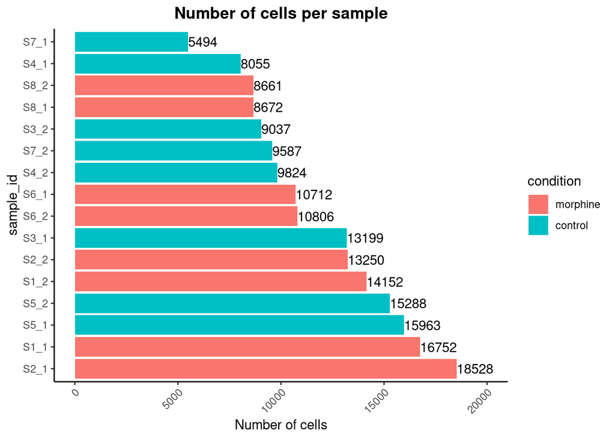

```r
cell_counts <- metadata2 %>%
               dplyr::count(sample_id) %>%
               left_join(metadata, by = c("sample_id" = "bcbio_id")) %>%
               dplyr::select(sample_id, sample_name, condition, n) %>%
               dplyr::rename(n_cells = n)

cell_counts %>% ggplot(aes(x = reorder(sample_name, -n_cells),
                           y = n_cells,
                           fill = condition)) +
                geom_col() +
                theme_classic() +
                theme(axis.text.x = element_text(angle = 45, vjust = 1, hjust = 1)) +
                xlab("sample_id") +
                ylab("Number of cells") +
                ylim(0, 20000) +
                coord_flip() +
                geom_text(aes(label = n_cells), hjust = "left") +
                theme(plot.title = element_text(hjust = 0.5, face = "bold")) +
                ggtitle("Number of cells per sample")
```

```r
cell_counts %>% arrange(n_cells)
```

| sample_id | sample_name | condition | n_cells |
| --- | --- | --- | --- |
| fenster2020-CTATTAAG | S7_1 | control | 5494 |
| fenster2020-CGTCTAAT | S4_1 | control | 8055 |
| fenster2020-TTATGCGA | S8_2 | morphine | 8661 |
| fenster2020-GAGCCTTA | S8_1 | morphine | 8672 |
| fenster2020-CTAAGCCT | S3_2 | control | 9037 |
| fenster2020-AAGGCTAT | S7_2 | control | 9587 |
| fenster2020-TCTCTCCG | S4_2 | control | 9824 |
| fenster2020-CCTAGAGT | S6_1 | morphine | 10712 |
| fenster2020-GCGTAAGA | S6_2 | morphine | 10806 |
| fenster2020-AAGGAGTA | S3_1 | control | 13199 |

[output cut: 6 more lines]

- Total cells:187980

# 3 Number of transcripts(UMIs) per cell

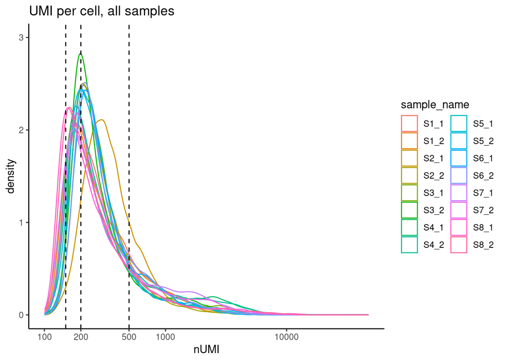

```r
metadata2 %>%
    ggplot(aes(color = sample_name, x = nUMI)) +
    geom_density(alpha = 0.2) +
    scale_x_log10(breaks = c(100, 200, 500, 1000, 10000)) +
    theme_classic() +
    geom_vline(xintercept = 150, linetype = "dashed") +
    geom_vline(xintercept = 200, linetype = "dashed") +
    geom_vline(xintercept = 500, linetype = "dashed") +
    ylim(0, 3) +
    guides(color = guide_legend(ncol = 2)) +
    ggtitle("UMI per cell, all samples")
```

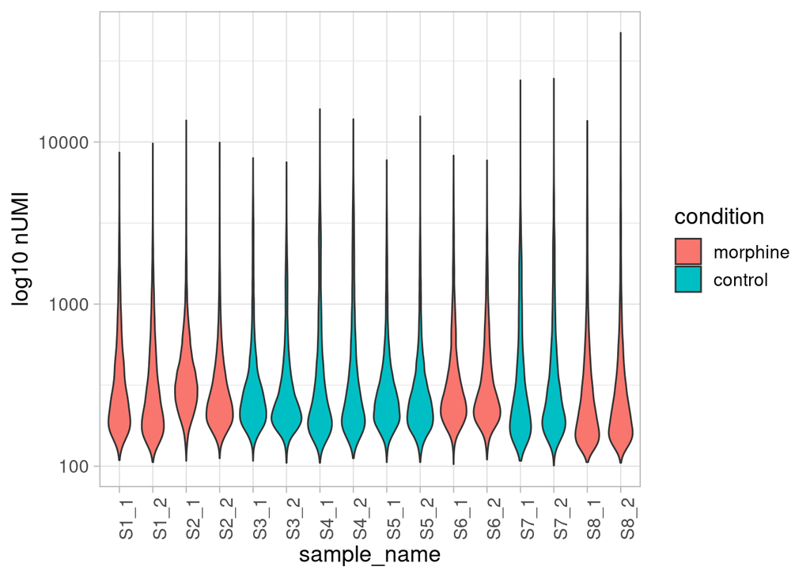

```r
metadata2 %>%
    ggplot(aes(sample_name, nUMI)) +
    geom_violin(aes(fill = condition)) +
    ylab("log10 nUMI") +
    geom_vline(xintercept = 500, linetype = "dashed") +
    scale_y_log10() +
    theme(axis.text.x = element_text(angle = 90, hjust = 1))
```

# 4 Distribution of genes detected per cell

## 4.1 Histogram

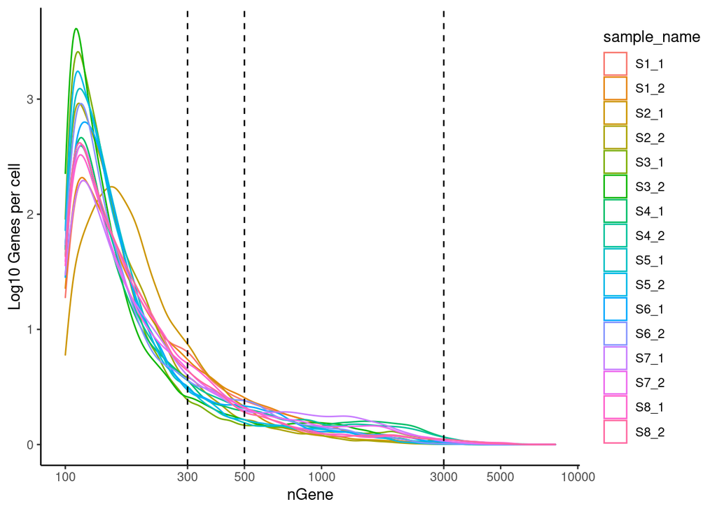

```r
metadata2 %>%
    ggplot(aes(color = sample_name,
               x = nGene)) +
    geom_density(alpha = 0.2) +
    theme_classic() +
    scale_x_log10(breaks = c(100, 300, 500, 1000, 3000, 5000, 10000)) +
    geom_vline(xintercept = 300, linetype = "dashed")+
    geom_vline(xintercept = 500, linetype = "dashed")+
    geom_vline(xintercept = 3000, linetype = "dashed")+
    ylab("Log10 Genes per cell")+
    guides(color = guide_legend(ncol = 1))
```

## 4.2 Boxplot

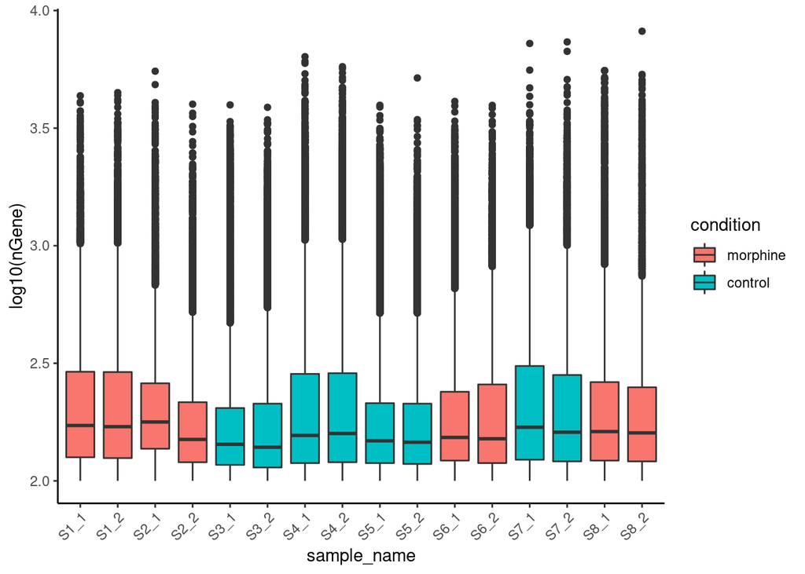

```r
metadata2 %>%
    ggplot(aes(x = sample_name,
               y = log10(nGene),
               fill = condition)) +
    geom_boxplot() +
    theme_classic() +
    theme(axis.text.x = element_text(angle = 45, vjust = 1, hjust=1)) +
    theme(plot.title = element_text(hjust = 0.5, face = "bold"))
```

## 4.3 Violin plot

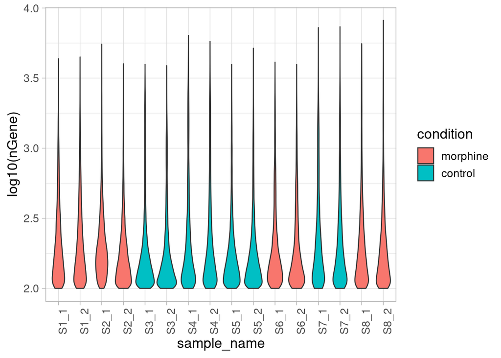

```r
metadata2 %>%
    ggplot(aes(x = sample_name, y = log10(nGene))) +
    geom_violin(aes(fill = condition)) +
        theme(axis.text.x = element_text(angle = 90, hjust = 1))
```

# 5 Correlation between genes detected and number of UMIs and determine whether strong presence of cells with low numbers of genes/UMIs

Poor quality cells are likely to have low genes and UMIs per cell. Therefore, a poor sample is likely to have cells in the lower left of the graph. Good cells should exhibit both higher number of genes per cell and higher numbers of UMIs. We also expect similar lines with similar slopes for all samples.

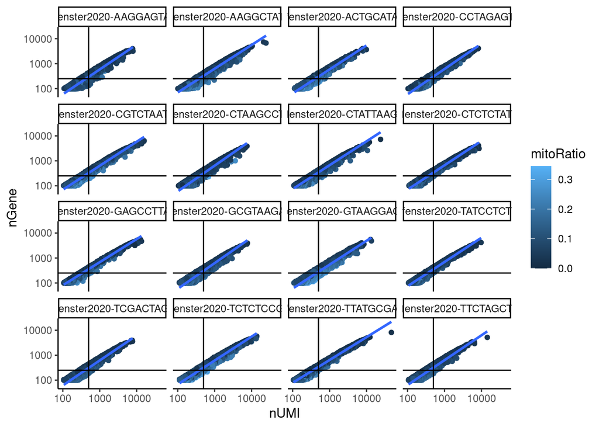

```r
metadata2 %>%
    ggplot(aes(x = nUMI, y = nGene, color = mitoRatio)) +
    geom_point() +
    stat_smooth(method=lm) +
    scale_x_log10() +
    scale_y_log10() +
    theme_classic() +
    geom_vline(xintercept = 500) +
    geom_hline(yintercept = 250) +
    facet_wrap(~sample_id)
```

# 6 Mitochondrial gene ratio

This metric can identify whether there is a higher than typical relative abundance of mitochondrial gene transcripts represented, indicative of dead or dying cells. Poor quality samples for mitochondrial counts would have larger peaks above the 0.1 mitochondrial ratio mark, unless it is expected based on sample type.

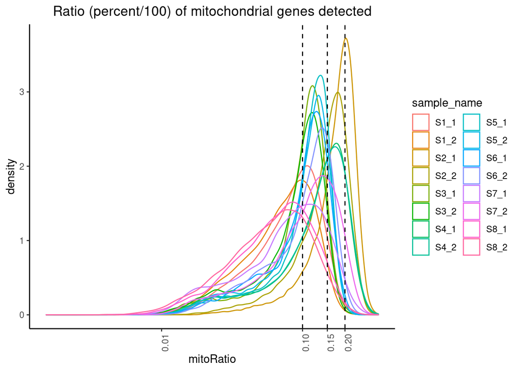

```r
metadata2 %>%
    ggplot(aes(color = sample_name,
               x = mitoRatio)) +
    geom_density(alpha = 0.2) +
    scale_x_log10(breaks = c(0.001, 0.010, 0.1, 0.15, 0.2)) +
    theme_classic() +
    ggtitle("Ratio (percent/100) of mitochondrial genes detected") +
    theme(plot.title = element_text(hjust = 0.5)) +
    theme(axis.text.x = element_text(angle = 90, hjust = 1))+
    geom_vline(xintercept = 0.1, linetype = "dashed") +
    geom_vline(xintercept = 0.15, linetype = "dashed") +
    geom_vline(xintercept = 0.2, linetype = "dashed") +
    guides(color = guide_legend(ncol = 2))
```

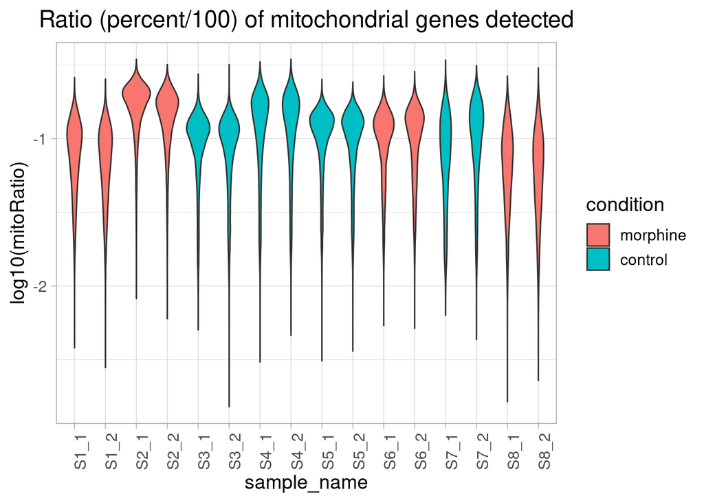

```r
metadata2 %>%
    ggplot(aes(x = sample_name,
               y = log10(mitoRatio))) +
    geom_violin(aes(fill = condition)) +
    theme(axis.text.x = element_text(angle = 90, hjust = 1)) +
    ggtitle("Ratio (percent/100) of mitochondrial genes detected") +
    theme(plot.title = element_text(hjust = 0.5))
```

# 7 Overall novelty of the gene expression by visualizing the genes detected per UMI

“Novelty” is the ratio of nGENE to nUMI, i.e. relative number of genes detected. Cells with relatively low “Novelty” have fewer genes detected per total UMI counts than average (a less complex RNA profile), and can indicate low quality cells, or contamination with less complex cell types like erythrocytes. Generally, we expect the novelty score to be above 0.80.

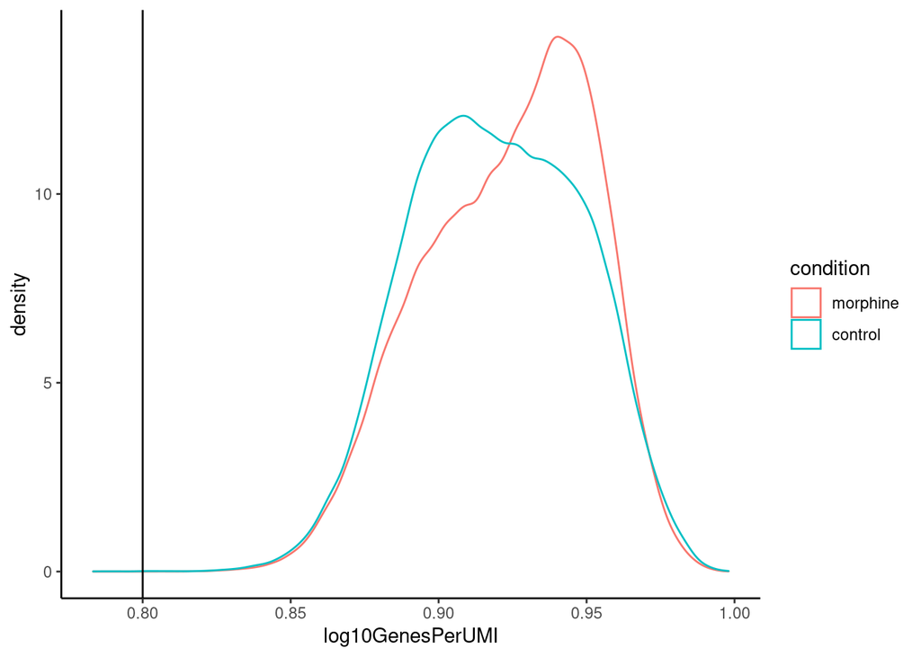

```r
metadata2 %>%
    ggplot(aes(x = log10GenesPerUMI,
               color = condition)) +
    geom_density(alpha = 0.2) +
    theme_classic() +
    geom_vline(xintercept = 0.8)
```

# 8 Filter: nGene in [300, 3000], mitoRatio < 0.10, keeping genes expression in >=10 cells

```r
cell_counts <- seurat_filtered@meta.data %>%
               count(sample_id) %>%
               left_join(metadata, by = c("sample_id" = "bcbio_id")) %>%
               dplyr::select(sample_id, n, sample_name, condition) %>%
               rename(n_cells = n)
```

- Total cells:31443
- Mean cells: 1965.1875
- Median cells: 1786.5

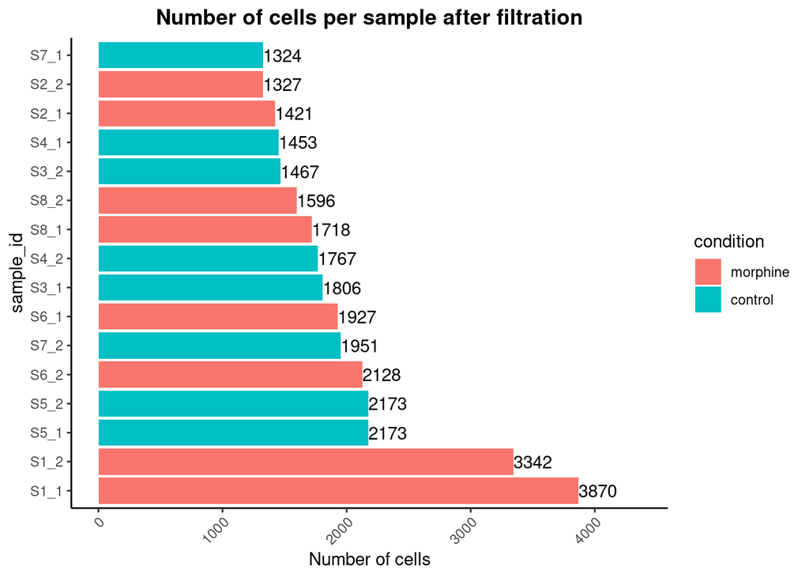

```r
y_max <- max(cell_counts$n_cells) + 500
cell_counts %>% ggplot(aes(x = reorder(sample_name, -n_cells),
                           y = n_cells,
                           fill = condition)) +
                geom_col() +
                theme_classic() +
                theme(axis.text.x = element_text(angle = 45, vjust = 1, hjust = 1)) +
                xlab("sample_id") +
                ylab("Number of cells") +
                ylim(0, y_max) +
                coord_flip() +
                geom_text(aes(label = n_cells), hjust = "left") +
                theme(plot.title = element_text(hjust = 0.5, face = "bold")) +
                ggtitle("Number of cells per sample after filtration")
```